# Descriptive Statistics 2: Measures of Central Tendency

# Introduction

In this lesson, we explore **Measures of Central Tendency** for numeric variables: Mean, Median, Mode.

# Learning Objectives

By the end of this lesson, you will be able to:

1. Compute and interpret measures of central tendency (mean, median, mode) in R.
2. Know which ones are appropriate for what.

# Packages

This lesson will require the following packages to be installed and loaded:

```r
# Load packages
if (!require(pacman)) install.packages("pacman")
pacman::p_load(
  tidyverse,
  here,
  janitor,
  DescTools,
)
```

# Recap: Methods of Descriptive analysis

Descriptive analysis of numerical variables can be measured by different methods (numerical or graphical) depending on the type of variable being summarized.

1. **Numerical Variables**
   - **Continuous**
     - **Numerical methods** (e.g., mean, median, variance)
     - **Graphical methods** (e.g., histogram, boxplot)
   - **Discrete**
     - **Numerical methods** (e.g., counts, proportions, discrete distributions)
     - **Graphical methods** (e.g., bar charts, histograms with integer bins)
2. **Categorical Variables**
   - **Ordinal** (clear order, e.g., Likert scale: *poor*, *fair*, *good*)
     - **Numerical methods** (e.g., frequencies, percentages)
     - **Graphical methods** (e.g., bar chart with ordered categories)
   - **Nominal** (no inherent order, e.g., gender, country)
     - **Numerical methods** (e.g., frequencies, proportions)
     - **Graphical methods** (e.g., bar chart, pie chart)

**TipKey Point**

There are both **numerical** and **graphical** methods we can use to perform descriptive analysis for all types and subtypes of variables.

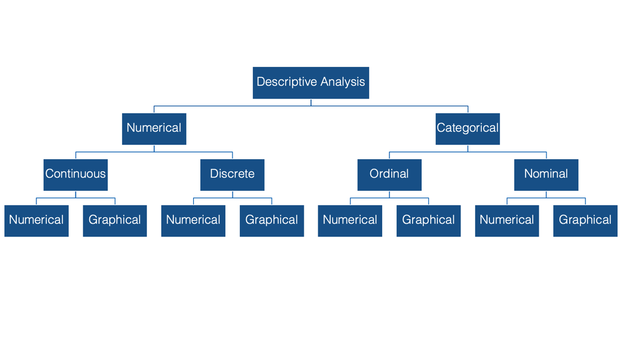

# The Yaounde COVID-19 dataset

```r
# Import data to RStudio
yaounde_raw <- read_csv(here("data/yaounde_data.csv"))
```

| id | date_surveyed | age | age_category | age_category_3 | sex | highest_education | occupation | weight_kg | height_cm | is_smoker | is_pregnant | is_medicated | neighborhood | household_with_children | breadwinner | source_of_revenue | has_contact_covid | igg_result | igm_result | symptoms | symp_fever | symp_headache | symp_cough | symp_rhinitis | symp_sneezing | symp_fatigue | symp_muscle_pain | symp_nausea_or_vomiting | symp_diarrhoea | … |
| --- | --- | --- | --- | --- | --- | --- | --- | --- | --- | --- | --- | --- | --- | --- | --- | --- | --- | --- | --- | --- | --- | --- | --- | --- | --- | --- | --- | --- | --- | --- |
| BRIQUETERIE_000_0001 | 2020-10-22 | 45 | 45 - 64 | Adult | Female | Secondary | Informal worker | 95 | 169 | Non-smoker | No | Yes | Briqueterie | No children | No response | Other | Recent COVID contact | Negative | Negative | Muscle pain | No | No | No | No | No | No | Yes | No | No | … |
| BRIQUETERIE_000_0002 | 2020-10-24 | 55 | 45 - 64 | Adult | Male | University | Salaried worker | 96 | 185 | Ex-smoker | NA | No | Briqueterie | No children | Other family | Regular, Formal--Regular, Commerce | No COVID contact | Positive | Negative | No symptoms | No | No | No | No | No | No | No | No | No | … |
| BRIQUETERIE_000_0003 | 2020-10-24 | 23 | 15 - 29 | Adult | Male | University | Student | 74 | 180 | Smoker | NA | Yes | Briqueterie | No children | No response | Other | No COVID contact | Negative | Negative | No symptoms | No | No | No | No | No | No | No | No | No | … |
| BRIQUETERIE_002_0001 | 2020-10-22 | 20 | 15 - 29 | Adult | Female | Secondary | Student | 70 | 164 | Non-smoker | No | No | Briqueterie | With children | Mother | Irregular, Commerce | No COVID contact | Positive | Negative | Rhinitis--Sneezing--Anosmia or ageusia | No | No | No | Yes | Yes | No | No | No | No | … |
| BRIQUETERIE_002_0002 | 2020-10-22 | 55 | 45 - 64 | Adult | Female | Primary | Trader--Farmer | 67 | 147 | Non-smoker | No | No | Briqueterie | With children | Mother | Regular, Informal--Irregular, Commerce--Other | No COVID contact | Positive | Negative | No symptoms | No | No | No | No | No | No | No | No | No | … |
| BRIQUETERIE_002_0003 | 2020-10-25 | 17 | 15 - 29 | Child | Female | Secondary | Student | 65 | 162 | Non-smoker | No | No | Briqueterie | With children | No response | Irregular, Commerce | No COVID contact | Negative | Negative | Fever--Cough--Rhinitis--Nausea or vomiting--Diarrhoea | Yes | No | Yes | Yes | No | No | No | Yes | Yes | … |
| BRIQUETERIE_002_0004 | 2020-10-25 | 13 | 5 - 14 | Child | Female | Secondary | Student | 65 | 150 | Non-smoker | No | No | Briqueterie | With children | No response | Other | No COVID contact | Positive | Negative | Sneezing | No | No | No | No | Yes | No | No | No | No | … |
| BRIQUETERIE_003_0001 | 2020-10-24 | 28 | 15 - 29 | Adult | Male | Doctorate | Student | 62 | 173 | Non-smoker | NA | No | Briqueterie | With children | No response | Irregular, Formal--Irregular, Commerce | No COVID contact | Negative | Negative | Headache | No | Yes | No | No | No | No | No | No | No | … |
| BRIQUETERIE_003_0002 | 2020-10-24 | 30 | 30 - 44 | Adult | Male | Secondary | Trader | 73 | 170 | Non-smoker | NA | No | Briqueterie | With children | No response | Irregular, Formal--Irregular, Commerce | No COVID contact | Negative | Negative | Fever--Rhinitis--Anosmia or ageusia | Yes | No | No | Yes | No | No | No | No | No | … |
| BRIQUETERIE_003_0003 | 2020-10-24 | 13 | 5 - 14 | Child | Female | Secondary | Other | 56 | 153 | Non-smoker | No | No | Briqueterie | With children | No response | Irregular, Formal--Irregular, Commerce | No COVID contact | Positive | Negative | No symptoms | No | No | No | No | No | No | No | No | No | … |

[output cut: 961 more lines]

```r
yaounde <- yaounde_raw %>%
  mutate(across(starts_with("is_drug"), as.logical),
         across(starts_with("n_"), as.integer),
         age_category_3 = factor(age_category_3,
                                 levels = c("Child", "Adult", "Senior")),
         is_smoker = factor(is_smoker,
                            levels = c("Non-smoker", "Ex-smoker", "Smoker")),
         highest_education = factor(highest_education,
                                    levels = c("No formal instruction",
                                               "Primary",
                                               "Secondary",
                                               "University",
                                               "Doctorate",
                                               "No response"))
         )
```

```r
head(yaounde)
```

| id | date_surveyed | age | age_category | age_category_3 | sex | highest_education | occupation | weight_kg | height_cm | is_smoker | is_pregnant | is_medicated | neighborhood | household_with_children | breadwinner | source_of_revenue | has_contact_covid | igg_result | igm_result | symptoms | symp_fever | symp_headache | symp_cough | symp_rhinitis | symp_sneezing | symp_fatigue | symp_muscle_pain | symp_nausea_or_vomiting | symp_diarrhoea | … |
| --- | --- | --- | --- | --- | --- | --- | --- | --- | --- | --- | --- | --- | --- | --- | --- | --- | --- | --- | --- | --- | --- | --- | --- | --- | --- | --- | --- | --- | --- | --- |
| BRIQUETERIE_000_0001 | 2020-10-22 | 45 | 45 - 64 | Adult | Female | Secondary | Informal worker | 95 | 169 | Non-smoker | No | Yes | Briqueterie | No children | No response | Other | Recent COVID contact | Negative | Negative | Muscle pain | No | No | No | No | No | No | Yes | No | No | … |
| BRIQUETERIE_000_0002 | 2020-10-24 | 55 | 45 - 64 | Adult | Male | University | Salaried worker | 96 | 185 | Ex-smoker | NA | No | Briqueterie | No children | Other family | Regular, Formal--Regular, Commerce | No COVID contact | Positive | Negative | No symptoms | No | No | No | No | No | No | No | No | No | … |
| BRIQUETERIE_000_0003 | 2020-10-24 | 23 | 15 - 29 | Adult | Male | University | Student | 74 | 180 | Smoker | NA | Yes | Briqueterie | No children | No response | Other | No COVID contact | Negative | Negative | No symptoms | No | No | No | No | No | No | No | No | No | … |
| BRIQUETERIE_002_0001 | 2020-10-22 | 20 | 15 - 29 | Adult | Female | Secondary | Student | 70 | 164 | Non-smoker | No | No | Briqueterie | With children | Mother | Irregular, Commerce | No COVID contact | Positive | Negative | Rhinitis--Sneezing--Anosmia or ageusia | No | No | No | Yes | Yes | No | No | No | No | … |
| BRIQUETERIE_002_0002 | 2020-10-22 | 55 | 45 - 64 | Adult | Female | Primary | Trader--Farmer | 67 | 147 | Non-smoker | No | No | Briqueterie | With children | Mother | Regular, Informal--Irregular, Commerce--Other | No COVID contact | Positive | Negative | No symptoms | No | No | No | No | No | No | No | No | No | … |
| BRIQUETERIE_002_0003 | 2020-10-25 | 17 | 15 - 29 | Child | Female | Secondary | Student | 65 | 162 | Non-smoker | No | No | Briqueterie | With children | No response | Irregular, Commerce | No COVID contact | Negative | Negative | Fever--Cough--Rhinitis--Nausea or vomiting--Diarrhoea | Yes | No | Yes | Yes | No | No | No | Yes | Yes | … |

# Numerical Variables

In previous sections you’ve seen methods for describing categorical variables. Now we’ll switch over to describing numerical variables, both numerically and graphically.

## Numerical Descriptions of Numerical Variables: Measures of Central Tendency

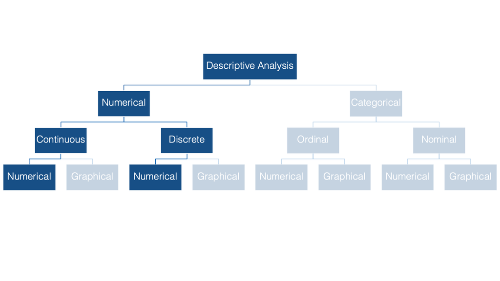

In epidemiology, we often want to describe the “typical” person in a population with respect to some characteristic that is recorded as a numerical variable, like height or weight. The most basic, and probably most commonly used, way to do so is with a **measure of central tendency**.

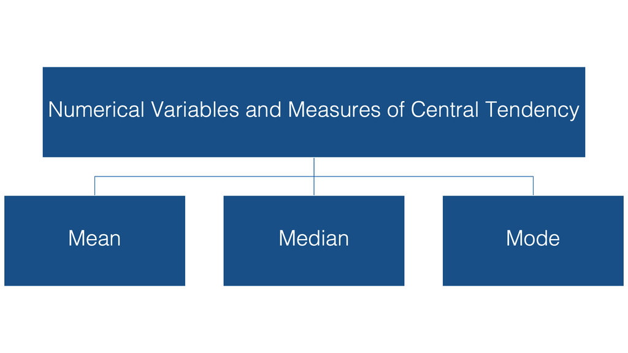

In this chapter we’ll discuss three measures of central tendency:

- **The mean**: The arithmetic average of the values.
- **The median**: The middle value when data are sorted.
- **The mode**: The most frequently occurring value(s).

Each of these have advantages and disadvantages, summarized in the chart below.

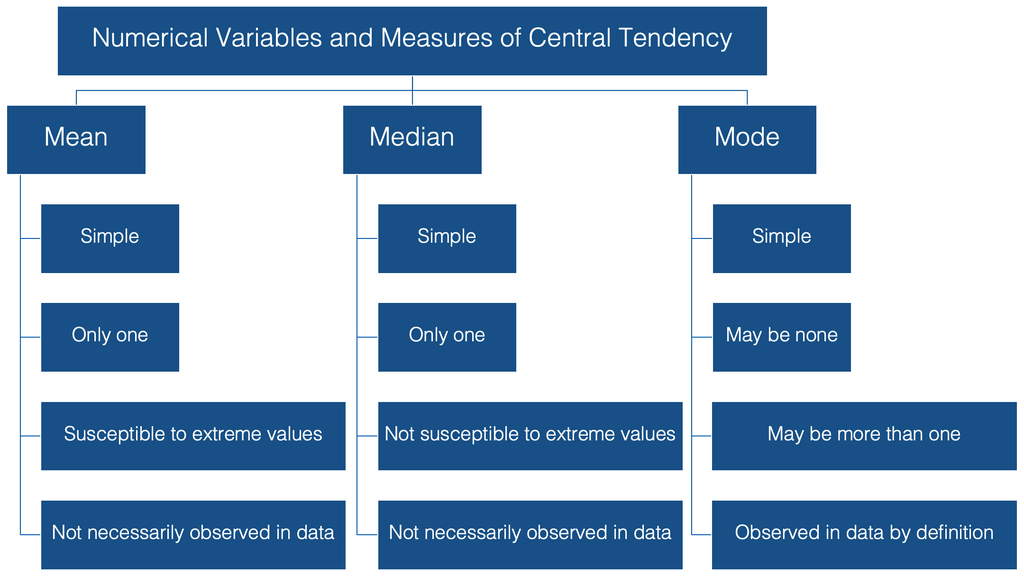

**TipKey Point**

Measures of central tendency summarize the “center” of a numerical distribution. They are sometimes referred to as measures of “location”. In public health, these measures help describe typical patient outcomes, average disease rates, and other key indicators.

**NotePractice**

**Measures of Central Tendency**

We measured the BMI of a group of individuals. Can you identify the median from the following values: 25, 24, 31, 38, 18, 14, 16, 25, 22, 25, 24, 27, 42, 30, 32?

### Mean

**Mean** is the sum of all the values in the data set divided by the number of values in the data set. It is also called the arithmetic average. The **sample mean** is denoted as x̅ and is read as **x bar**.

The formula to calculate the mean is:

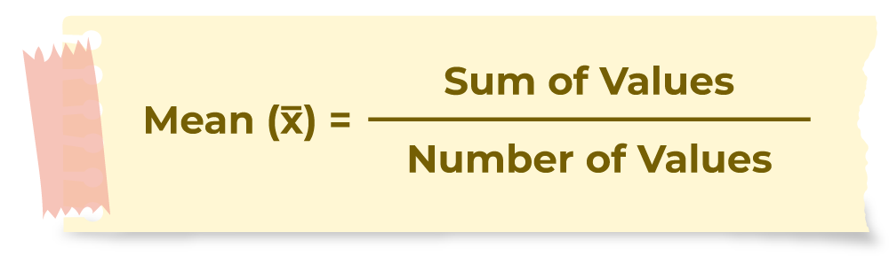

We can perform this calculation with the `mean()` function from base R.

```r
# Demonstration using a single numerical variable: "height_cm"
mean_height <- mean(yaounde$height_cm)
mean_height
```

```
[1] 158.9444
```

**WarningNotation Alert**

The **sample mean** is denoted by the Latin letter $\bar{x}$.

The **population mean** is denoted by the Greek letter $\mu$.

This will become important in later steps when we calculate standard deviation, standard error, confidence intervals, and more.

### Median

A Median is a middle value for sorted data. The sorting of the data can be done either in ascending order or descending order. A median divides the data into two halves.

The formula to calculate the median of the number of terms if the number of terms is odd is shown in the image below:

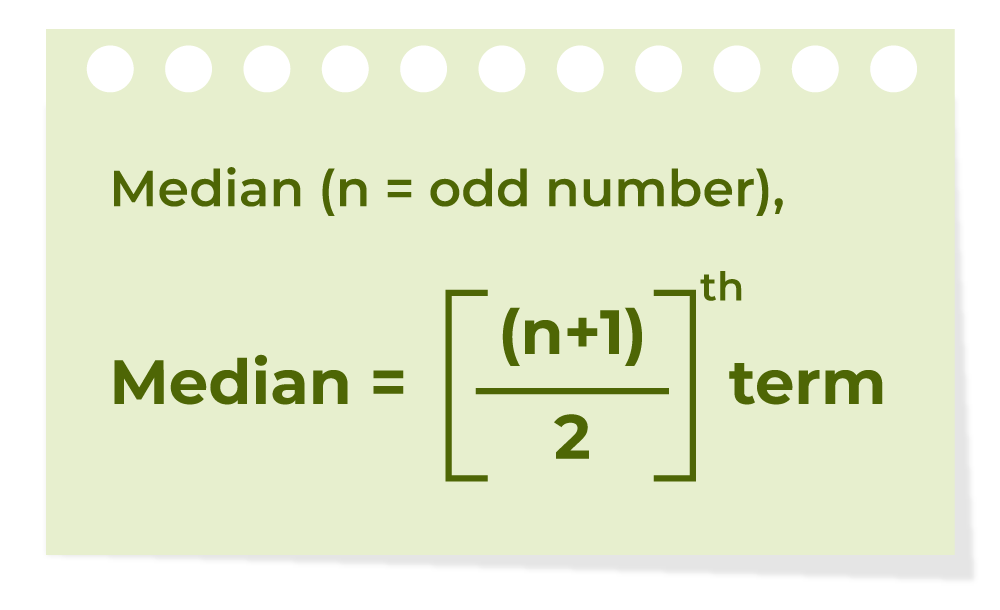

The formula to calculate the **median** of the number of terms if the number of terms is even is shown in the image below:

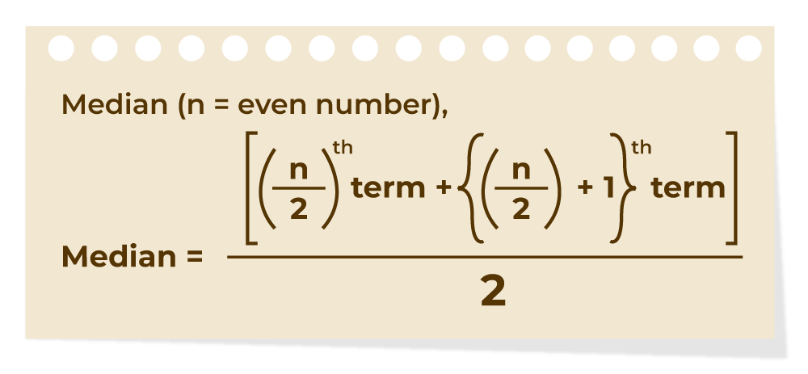

We can perform this calculation with the `median()` function from base R.

```r
median_height <- median(yaounde$height_cm)
median_height
```

```
[1] 164
```

### Mode

A mode is the most frequent value or item of the data set. There is no mode for a data set if every number appears only once.

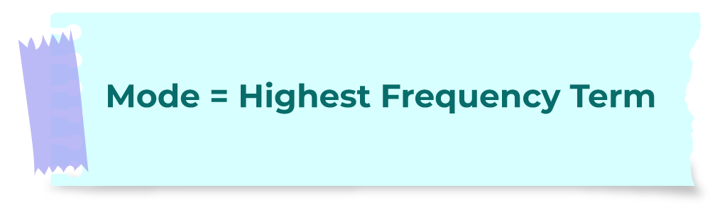

Base R does not have a built-in function for calculating the mode, so we can use the `Mode()` function from the `{DescTools}` package.

```r
mode_height <- Mode(yaounde$height_cm)
mode_height
```

```
[1] 165
attr(,"freq")
[1] 67
```

**WarningMissing values when calculating measures of central tendency**

If there are missing values you can exclude them by adding `na.rm = TRUE`

```r
# Returns NA because there are missing values in this column
mean(yaounde$n_bedridden_days)
```

```
[1] NA
```

```r
# Successfully calculates the mean
mean(yaounde$n_bedridden_days, na.rm = TRUE)
```

```
[1] 1.145763
```

The same applies to the `median()` and `Mode()` functions:

```r
Mode(yaounde$n_bedridden_days, na.rm = TRUE)
```

```
[1] 0
attr(,"freq")
[1] 192
```

The most frequent value was 0: 192 respondents were not bedridden at all.

**NotePractice**

**Calculating Measures of Central Tendency in R**

Use `mean()`, `median()`, and `Mode()` to compute the following:

1. Mean of `weight_kg`.
2. Median of `n_days_miss_work` (be sure to handle missing values).
3. Mode of `age` and `respiration_frequency`.

### Differences between Mean, Median, and Mode

Mean, median, and mode are measures of central tendency in statistics.

[output not shown]

# Graphing measures of central tendency

Base plot of height distribution

```r
# Histogram and density curve showing distribution of height_cm
base_histogram <- ggplot(
  data = yaounde,
  mapping = aes(x = height_cm)
) +
  geom_histogram(
    color = "white",
    fill = "steelblue", binwidth = 5,
    mapping = aes(y = after_stat(density))
  ) +
    geom_density(
    color = "indianred2",
    alpha = 0.25,
    linewidth = 1,
    bw = 3
  ) +
  scale_x_continuous(
    breaks = scales::pretty_breaks(n = 12),
    expand = c(0, 0)
  ) +
  scale_y_continuous(expand = c(0, 0))
```

```r
# Add vertical lines to mark the mean, median, and mode
mmm_histogram <- base_histogram +
  geom_vline(aes(xintercept = mean(height_cm)),
    linetype = "dotted", linewidth = 1
  ) +
  geom_vline(aes(xintercept = median(height_cm)),
    linetype = "dashed", linewidth = 1, color = "red"
  )  +
  geom_vline(aes(xintercept = Mode(height_cm)),
             linewidth = 1, color = "darkgreen"
  )
```

What if we filter out the children and plot the histogram again?

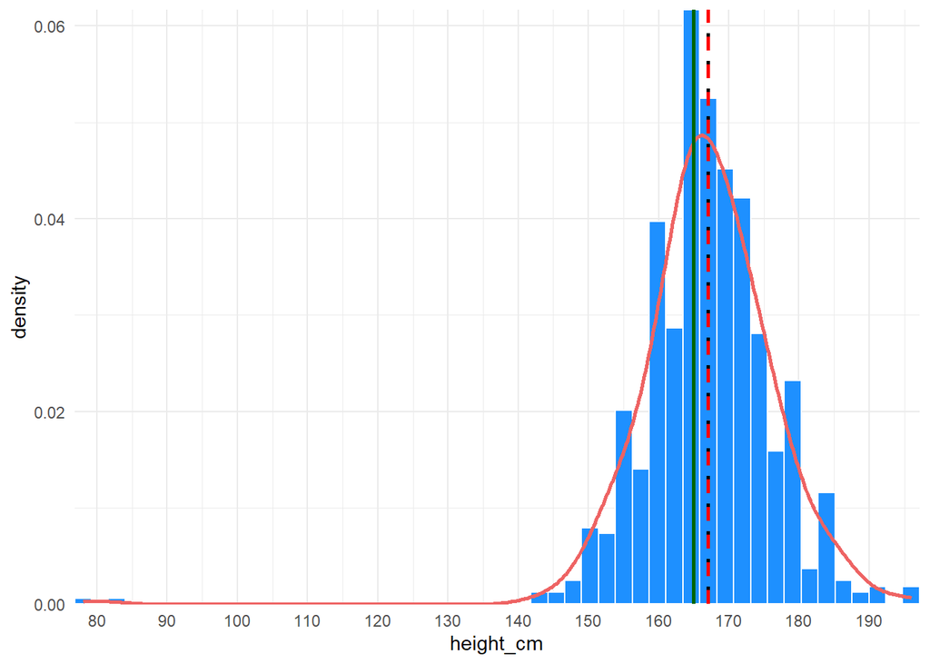

```r
# Create new df of only adults
yao_adults <- yaounde %>% filter(age_category_3 != "Child")

# Define base ggplot layers
yao_adults_height <- ggplot(
  data = yao_adults,
  mapping = aes(x = height_cm)
) +
  scale_x_continuous(
    breaks = scales::pretty_breaks(n = 12),
    expand = c(0, 0)
  ) +
  scale_y_continuous(expand = c(0, 0))

yao_adults_height +
  geom_histogram(
    bins = 50,
    color = "white",
    fill = "dodgerblue",
    mapping = aes(y = after_stat(density))
  ) +
  geom_density(
    color = "indianred2",
    alpha = 0.25,
    linewidth = 1,
    bw = 3
  ) +
  geom_vline(aes(xintercept = mean(height_cm)),
    linetype = "dotted", linewidth = 1
  ) +
  geom_vline(aes(xintercept = median(height_cm)),
    linetype = "dashed", linewidth = 1, color = "red"
  )  +
  geom_vline(aes(xintercept = Mode(height_cm)),
             linewidth = 1, color = "darkgreen"
  )
```

**NotePractice: Graphing Mean, Median, and Mode**

A. Create a new data frame called `yao_male_adults` which filters `yaounde` to keep only the rows where `sex` is “Male” and `age_category_3` is “Adult”.

B. Calculate the mean, median, and mode of `height_cm` in `yao_male_adults`.

C. Use {ggplot2} code to plot a histogram/density curve of `height_cm` with vertical lines for mean, median, and mode.

**NotePractice: Identifying Skew**

A. Using the `yaounde` data frame, plot a simple histogram or density curve of the **`age`** variable.

B. Visually assess the shape of the distribution. Is it left-skewed, right skewed, or not skewed?

C. Create a boxplot showing the distribution of `age` for each `sex`. Add points to mark the mean and mode using `stat_summary()`.

D. Based on the positions of the mean, median, and mode, which sex has the more skewed distribution?

# Symmetry and Skew

## Identifying skew

Rather than just visually assessing skew from the shape of a curve, we can also numerically assess it by looking at where the mean, median, and mode fall relative to one another in a distribution. In a **symmetric** distribution, the three are approximately equal. In a **right-skewed** (positively skewed) distribution, the mode is smallest, followed by the median, then the mean, because the mean is pulled toward the long right tail. In a **left-skewed** (negatively skewed) distribution, the order is reversed: the mean is smallest, then the median, then the mode.

Identifying skew (non-normality) in the data is important because our choice of statistical tests depends on the distribution of the data.

- When continuous data are (approximately) normally distributed, we use **parametric tests** such as t-tests, ANOVA, Pearson correlation.
- Otherwise we use **non-parametric tests** such as Mann-Whitney U test, Kruskal-Wallis test, chi-square test.

## Assessing symmetry

1. Visual tests
2. Summary statistics
   - Median similar to mean
   - SD > mean
   - Coefficient of skewness

[figure not shown]

When normal, distribution can be summarized by mean and standard deviation. If not, median or mode may be more appropriate.

# Key Takeaways

- **Descriptive analysis** begins with identifying **variable types**: numerical vs. categorical, then diving deeper (continuous, discrete, ordinal, nominal).
- **Measures of central tendency** (mean, median, mode) can be used to describe the “center” of a numeric distribution. Each have unique properties:
  - **Mean** is sensitive to outliers.
  - **Median** is more robust to skewness.
  - **Mode** is always an observed value, but may not be unique or might not exist in certain distributions.
- **Graphical summaries** (histograms, kernel density curves, boxplots) reveal patterns not always evident from numerical summaries alone.

Continue exploring these concepts with real-world data to gain deeper insight into public health analyses.

# Answer Key

**Calculating Measures of Central Tendency in R**

Use `mean()`, `median()`, and `Mode()` to compute the following:

1. Mean of `weight_kg`.

```r
mean(yaounde$weight_kg)
```

```
[1] 64.40577
```

2. Median of `n_days_miss_work` (be sure to handle missing values).

```r
median(yaounde$n_days_miss_work, na.rm = TRUE)
```

```
[1] 0
```

3. Mode of `age` and `respiration_frequency`.

```r
Mode(yaounde$age)
```

```
[1] 8
attr(,"freq")
[1] 33
```

```r
Mode(yaounde$respiration_frequency, na.rm = T)
```

```
[1] 15
attr(,"freq")
[1] 4
```

**Graphing Mean, Median, and Mode**

A. Create a new data frame called `yao_male_adults` which filters `yaounde` to keep only the rows where `sex` is “Male” and `age_category_3` is “Adult”.

```r
yao_male_adults <- yaounde %>%
  filter(age_category_3 == "Adult",
         sex == "Male")

yao_male_adults
```

```
# A tibble: 267 × 53
   id    date_surveyed   age age_category age_category_3 sex   highest_education
   <chr> <date>        <dbl> <chr>        <fct>          <chr> <fct>
 1 BRIQ… 2020-10-24       55 45 - 64      Adult          Male  University
 2 BRIQ… 2020-10-24       23 15 - 29      Adult          Male  University
 3 BRIQ… 2020-10-24       28 15 - 29      Adult          Male  Doctorate
 4 BRIQ… 2020-10-24       30 30 - 44      Adult          Male  Secondary
 5 BRIQ… 2020-11-18       42 30 - 44      Adult          Male  Secondary
 6 BRIQ… 2020-11-18       38 30 - 44      Adult          Male  University
 7 BRIQ… 2020-10-22       54 45 - 64      Adult          Male  University
 8 BRIQ… 2020-10-22       18 15 - 29      Adult          Male  Secondary
 9 BRIQ… 2020-10-25       42 30 - 44      Adult          Male  Primary
10 BRIQ… 2020-10-24       28 15 - 29      Adult          Male  Secondary
# ℹ 257 more rows
# ℹ 46 more variables: occupation <chr>, weight_kg <dbl>, height_cm <dbl>,
#   is_smoker <fct>, is_pregnant <chr>, is_medicated <chr>, neighborhood <chr>,
#   household_with_children <chr>, breadwinner <chr>, source_of_revenue <chr>,
#   has_contact_covid <chr>, igg_result <chr>, igm_result <chr>,
#   symptoms <chr>, symp_fever <chr>, symp_headache <chr>, symp_cough <chr>,
#   symp_rhinitis <chr>, symp_sneezing <chr>, symp_fatigue <chr>, …
```

B. Calculate the mean, median, and mode of `height_cm` in `yao_male_adults`.

```r
mean(yao_male_adults$height_cm)
```

```
[1] 172.7903
```

```r
median(yao_male_adults$height_cm)
```

```
[1] 172
```

```r
Mode(yao_male_adults$height_cm)
```

```
[1] 170
attr(,"freq")
[1] 21
```

C. Use {ggplot2} code to plot a histogram/density curve of `height_cm` with vertical lines for mean, median, and mode.

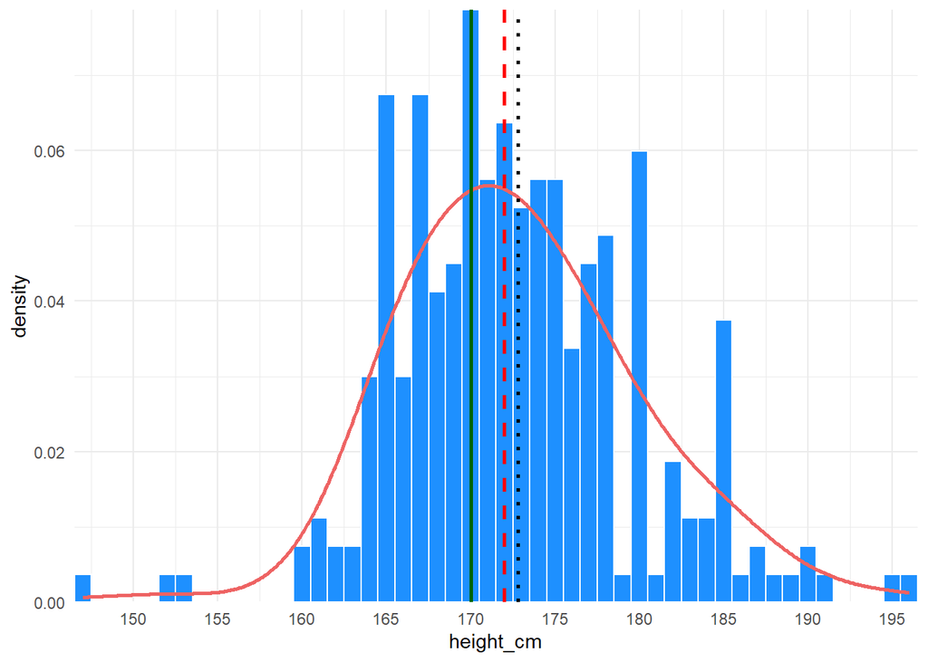

```r
ggplot(
  data = yao_male_adults,
  mapping = aes(x = height_cm)
) +
  scale_x_continuous(
    breaks = scales::pretty_breaks(n = 12),
    expand = c(0, 0)
  ) +
  scale_y_continuous(expand = c(0, 0)) +
  geom_histogram(
    bins = 50,
    color = "white",
    fill = "dodgerblue",
    mapping = aes(y = after_stat(density))
  ) +
  geom_density(
    color = "indianred2",
    alpha = 0.25,
    linewidth = 1,
    bw = 3
  ) +
  geom_vline(aes(xintercept = mean(height_cm)),
    linetype = "dotted", linewidth = 1
  ) +
  geom_vline(aes(xintercept = median(height_cm)),
    linetype = "dashed", linewidth = 1, color = "red"
  )  +
  geom_vline(aes(xintercept = Mode(height_cm)),
             linewidth = 1, color = "darkgreen"
  )
```

**Identifying Skew**

A. Using the `yaounde` data frame, plot a simple histogram or density curve of the **`age`** variable.

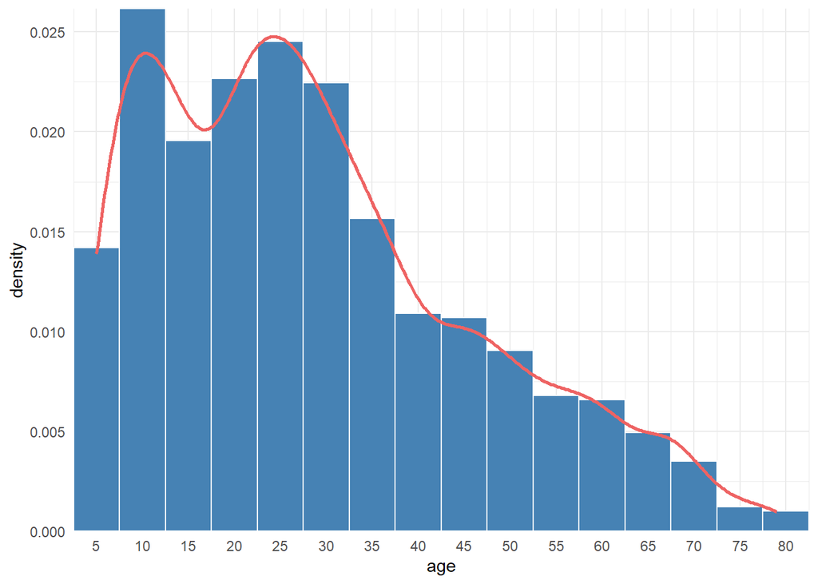

```r
ggplot(
  data = yaounde,
  mapping = aes(x = age)
) +
  geom_histogram(
    color = "white",
    fill = "steelblue", binwidth = 5,
    mapping = aes(y = after_stat(density))
  ) +
    geom_density(
    color = "indianred2",
    alpha = 0.25,
    linewidth = 1,
    bw = 3
  ) +
  scale_x_continuous(
    breaks = scales::pretty_breaks(n = 12),
    expand = c(0, 0)
  ) +
  scale_y_continuous(expand = c(0, 0))
```

B. Visually assess the shape of the distribution. Is it left-skewed, right skewed, or not skewed?

C. Create a boxplot showing the distribution of `age` for each `sex`. Add points to mark the mean and mode using `stat_summary()`.

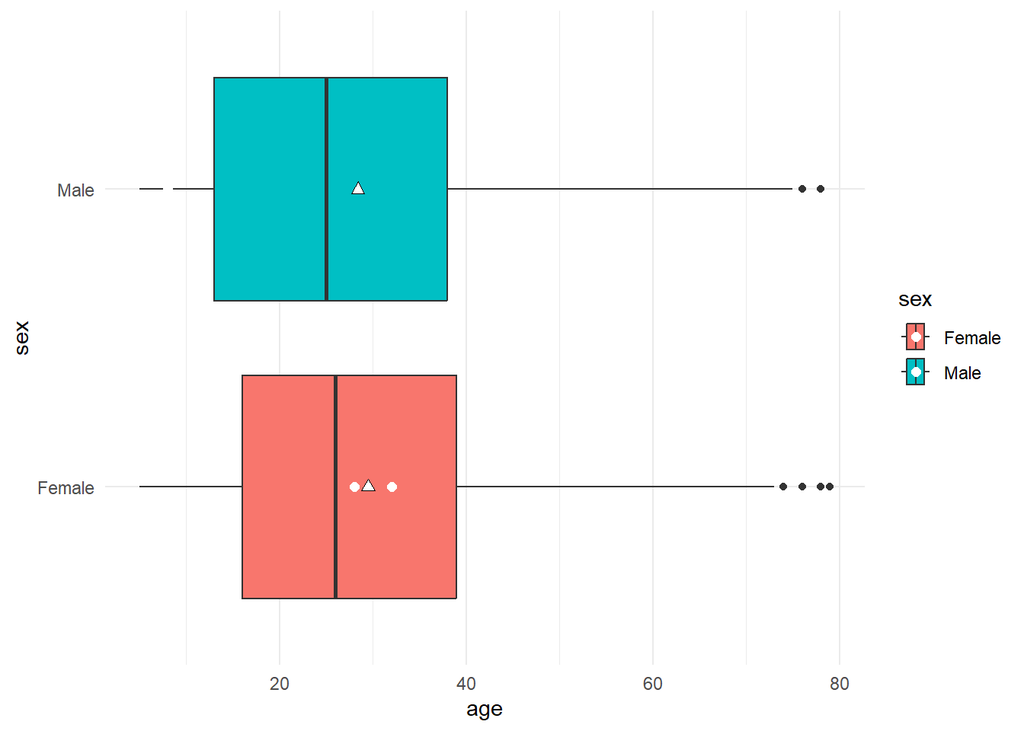

```r
ggplot(
  data = yaounde,
  mapping = aes(x = age, y = sex, fill = sex)
) + geom_boxplot() +
  stat_summary(
    fun = "Mode",
    geom = "point",
    size = 2, color = "white")+
  stat_summary(
    fun = "mean",
    geom = "point",
    size = 2,
    shape = 24, fill = "white")
```

D. Based on the positions of the mean, median, and mode, which sex has the more skewed distribution?

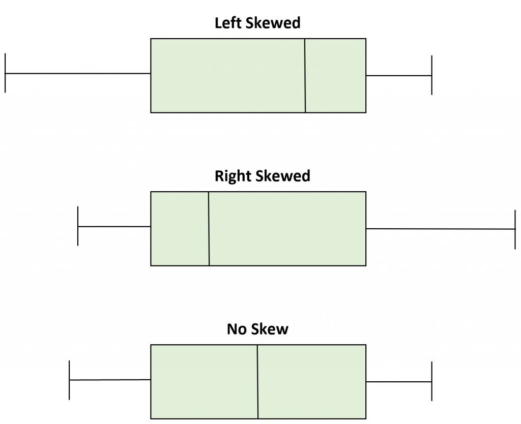

# Contributors

The following team members contributed to this lesson:

- [JOY VAZ](https://thegraphcourses.org/members/joy)  
  R Instructor and Mathematical Modeller, The GRAPH Network

  Loves doing science and teaching science
- [KENE DAVID NWOSU](https://thegraphcourses.org/members/kendavidn/)  
  Data analyst, The GRAPH Network

  Passionate about world improvement

# References

Some material in this lesson was adapted from the following sources:

- Irizarry, Rafael A. 2019. *Introduction to Data Science: Statistics and Prediction Algorithms Through Case Studies*. https://rafalab.dfci.harvard.edu/dsbook-part-2/.
- Cannell, Brad, and Melvin Livingston. n.d. *R for Epidemiology*. https://www.r4epi.com/.
- GeeksforGeeks. 2025. “Introduction of Statistics and Its Types.” https://www.geeksforgeeks.org/introduction-of-statistics-and-its-types/.
- Starmer, Josh. *StatQuest with Josh Starmer* [YouTube Channel]. https://www.youtube.com/channel/UCtYLUTtgS3k1Fg4y5tAhLbw.
- The GRAPH Courses. *FoSSA: Fundamentals of Statistical Software & Analysis*. https://thegraphcourses.org/courses/fossa/.
- University of Miami Libraries. *Introduction to Data Analysis and R*. https://www.library.miami.edu/data-services/data-analysis.html.

This work is licensed under the [Creative Commons Attribution Share Alike](https://creativecommons.org/licenses/by-sa/4.0/) license.